# Time Series: A First Course with Bootstrap Starter

# Lesson 4-2: The L2 Space

- We use *Hilbert Spaces* to think about time series prediction (i.e., forecasting).
- A Hilbert Space is a vector space with inner product, where Cauchy sequences converge.

## The Space ${\mathbb L}_2$

- For a given probability space, let ${\mathbb L}_2$ denote all random variables with finite second moment.
- Define an inner product on ${\mathbb L}_2$ as follows:
  $$\langle X, Y \rangle = {\mathbb E} [ X Y ]$$
  for $X,Y \in {\mathbb L}_2$.
- The *norm* is $\| X \| = \sqrt{ \langle X, X \rangle}$.
- ${\mathbb L}_2$ is a Hilbert Space.

## Cauchy-Schwarz

- The Cauchy-Schwarz inequality holds. If the random variables are mean zero, it says that
  $$| \mbox{Cov} [X,Y] | \leq \sqrt{ \mbox{Var}[X] \mbox{Var} [Y] }.$$
- This is equivalent to $|\mbox{Corr} [X,Y] | \leq 1$.

## Angle Between Random Variables

- Heuristically we can think of $\theta$ as the angle between $X, Y \in {\mathbb L}_2$, with
  $$\cos (\theta) = \frac{ \langle X, Y \rangle }{ \| X \| \| Y \|}.$$
- Hence the inner product is zero if $\theta = \pi/2$, i.e., the random variables are *orthogonal*.
- So when mean zero random variables have zero covariance (or correlation), they are orthogonal. We say they are *collinear* if their correlation is $\pm 1$.

## Paradigm 4.2.5. Projection

- We can project $Y$ onto $X$ by finding a scalar $a$ such that $X$ is orthogonal to $Y - aX$.
- So $0 = \langle X, Y - a X\rangle$, or $\langle X, Y \rangle = a {\| X \|}^2$, yielding
  $$a = \frac{ \langle X, Y \rangle }{ { \| X \|}^2 }.$$
- In summary, the projection of $Y$ onto $X$ is
  $$\widehat{Y} = \frac{ \langle X, Y \rangle }{ { \| X \|}^2 } X.$$
- If the random variables are mean zero, this is
  $$\widehat{Y} = \frac{ \mbox{Cov} [ X,Y] }{ \mbox{Var} [ X] } X.$$

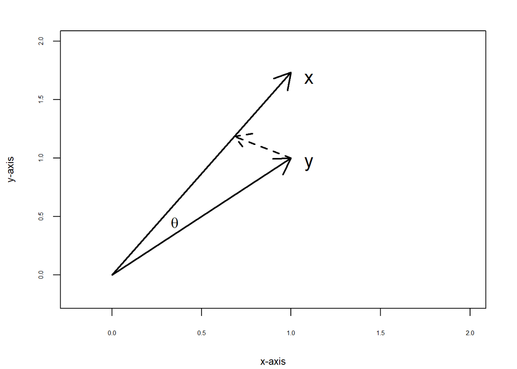

```r
par(mar=c(4,4,2,2)+0.1,cex.lab=.8)
plot(NA, xlim=c(-.2,2), ylim=c(-.2,2),xlab="x-axis",ylab="y-axis",yaxt="n",xaxt="n")
axis(1,cex.axis=.5)
axis(2,cex.axis=.5)
x0 <- c(0,0,1,sqrt(3))
y0 <- c(0,0,1,1)
arrows(x0[1],x0[2],x0[3],x0[4],col=1,lwd=2)
arrows(y0[1],y0[2],y0[3],y0[4],col=1,lwd=2)
text(1.1,sqrt(3)-.05,"x",cex=1.5)
text(1.1,.95,"y",cex=1.5)
x <- c(1,sqrt(3))
y <- c(1,1)
dot <- sum(x*y)
proj <- (dot/sum(x^2))*x
z0 <- c(0,0,proj[1],proj[2])
#arrows(z0[1],z0[2],z0[3],z0[4],col=1,lwd=2)
w0 <- c(1,1,proj[1],proj[2])
arrows(w0[1],w0[2],w0[3],w0[4],lwd=2,lty=2)
text(.35,.45,expression(theta),cex=1.2,col=1)
```